# Assignment one, key

Brendan Brown

# Rubric

## Points per question

Max score is 100

1. 3
2. 2
3. 10
4. 3
5. 12
6. 12
7. 10
8. 3
9. 10
10. 3
11. 12
12. (Open-ended) 20

## Possible deductions per question

1. -1.5 per sub-question for failing to produce the correct output or for failing to use the methods requested. `Correct’ here and below means the output should match exactly the solution. If the code does not run, the output is incorrect.
2. -2 for failing to produce the correct output.
3. -4 each for having an incorrect mean salary or for producing the incorrect output data frame. -3 for giving no answer to the written question, and -1.5 for giving an answer with insufficient justification. Here, you just need to give one credible reason why neurosurgeons are well-paid.
4. -3 for failing to give the correct answer.
5. -2 for not ordering the data frame as asked, -2 for including fewer or more columns than asked—each error will only be counted once, so if you made the same mistake for the chained non-chained answers you were deducted only once. -4 each for not including one of the methods for producing the data frame. -4 for not including the correct histogram. See below for other possible graph-related deductions.
6. -6 each for not including any plots. -3 each for not having one of these components on a plot: faceting, correct departments, correct plot type if specified.
7. -3 each for incorrect output — including incorrectly naming the data frame. You will only be deducted once for using the wrong data frame object name. -3 for an absent answer to the written question. -1.5 for including an answer with insufficient explanation.

8 . -3 for not producing the correct output.

9. -3 for failing to create a datetime variable or using another method to extract a year variable, -7 for failing to properly calculate the number of employees hired or which had the most.
10. -3 for failing to have the correct output.
11. -6 each for failing to produce plots with the correct variables and departments. Even if you produced plots, you might lose points for clarity of presentation. See details below.
12. (Open-ended) -3 each for each of three graphs not included. -2 for each written explanation related to a graph not included. -5 for failing to include a written explanation of findings. -2.5 for a written explanation that is poorly conceived. See below for other possible deductions for written communications.

## Additional deductions

- -7 if at least one of your markdown document failed to knit. It might seem harsh, but that is something you always should check to be sure is correct before submitting. If your document doesn’t run, you likely have code syntax errors for which you were not additionally deducted points.
- -1 for grammatical or other written communications errors, such as poor or unclear syntax and dangling modifiers. Maximum one deduction per sentence.
- -2 each for having at least one illegible axis or legend in a plot, for indecipherable plot output (such as white on white plotting), or for failing to include axis labels or plot legends altogether. Maximum 5 points deducted total for this. If you lose points for failing to produce a required plot, you do not also have points taken off for those style issues, of course.

# Prep

```r
library(tidyverse)
data <- read_csv("http://ryanthornburg.com/wp-content/uploads/2015/05/UNC_Salares_NandO_2015-05-06.csv")

glimpse(data)
```

```
## Observations: 12,287
## Variables: 14
## $ name     <chr> "AARON, NANCY G", "ABARBANELL, JEFFERY S", "ABARE, BE...
## $ campus   <chr> "UNC-CH", "UNC-CH", "UNC-CH", "UNC-CH", "UNC-CH", "UN...
## $ dept     <chr> "Romance Languages", "Kenan-Flagler Business School",...
## $ position <chr> "Senior Lecturer", "Associate Professor", "Research T...
## $ exempt2  <chr> "Exempt", "Exempt", "Subject to State Personnel Act",...
## $ employed <int> 9, 9, 12, 12, 12, 12, 12, 12, 12, 12, 12, 12, 9, 9, 1...
## $ hiredate <int> 20030701, 19990101, 20110912, 20090420, 20120103, 200...
## $ fte      <dbl> 1.00, 1.00, 1.00, 1.00, 1.00, 1.00, 1.00, 1.00, 1.00,...
## $ status   <chr> "Fixed-Term", "Continuing", "Permanent", "Permanent",...
## $ stservyr <int> 11, 17, 3, 5, 2, 15, 34, 11, 27, 2, 19, 7, 6, 21, 4, ...
## $ statesal <int> 46350, 173000, 0, 0, 41696, 56588, 41707, 0, 0, 0, 10...
## $ nonstsal <int> 0, 0, 38170, 50070, 0, 4412, 0, 80227, 55803, 32889, ...
## $ totalsal <int> 46350, 173000, 38170, 50070, 41696, 61000, 41707, 802...
## $ age      <int> 55, 57, 54, 29, 35, 41, 62, 36, 64, 26, 51, 41, 63, 6...
```

```r
summary(data)
```

```
##      name              campus              dept
##  Length:12287       Length:12287       Length:12287
##  Class :character   Class :character   Class :character
##  Mode  :character   Mode  :character   Mode  :character
##
##
##
##    position           exempt2             employed        hiredate
##  Length:12287       Length:12287       Min.   : 9.00   Min.   :19570901
##  Class :character   Class :character   1st Qu.:12.00   1st Qu.:20010701
##  Mode  :character   Mode  :character   Median :12.00   Median :20070901
##                                        Mean   :11.64   Mean   :20050068
##                                        3rd Qu.:12.00   3rd Qu.:20120618
##                                        Max.   :12.00   Max.   :20140929
##       fte          status             stservyr        statesal
##  Min.   :0.00   Length:12287       Min.   : 0.00   Min.   :     0
##  1st Qu.:1.00   Class :character   1st Qu.: 4.00   1st Qu.:     0
##  Median :1.00   Mode  :character   Median : 9.00   Median :  2696
##  Mean   :0.97                      Mean   :10.68   Mean   : 31372
##  3rd Qu.:1.00                      3rd Qu.:15.00   3rd Qu.: 50000
##  Max.   :1.00                      Max.   :57.00   Max.   :520000
##     nonstsal         totalsal           age
##  Min.   :     0   Min.   :  3000   Min.   :21.00
##  1st Qu.:     0   1st Qu.: 41884   1st Qu.:37.00
##  Median : 38239   Median : 59342   Median :46.00
##  Mean   : 49567   Mean   : 80938   Mean   :46.32
##  3rd Qu.: 64763   3rd Qu.: 92865   3rd Qu.:56.00
##  Max.   :625686   Max.   :819069   Max.   :89.00
```

Since we will be filtering by department names a lot, you at a minimum want to do a spot-check to be sure there are no typos —say orthopedics or radioligy. In a real project, you will do many more quality checks than this. The output is omitted.

```r
unique(data$dept) %>% sort
```

## Question 1

Return a data frame with columns: name, dept, age,totalsal

```r
select(data, name, dept, age, totalsal)
```

```
## # A tibble: 12,287 × 4
##                         name                          dept   age totalsal
##                        <chr>                         <chr> <int>    <int>
## 1             AARON, NANCY G             Romance Languages    55    46350
## 2      ABARBANELL, JEFFERY S Kenan-Flagler Business School    57   173000
## 3               ABARE, BETSY  Institute of Marine Sciences    54    38170
## 4             ABATE, AARON B       Medicine Administration    29    50070
## 5         ABATEMARCO, JODI M           School of Education    35    41696
## 6  ABBOTT-LUNSFORD, SHELBY L       Medicine Administration    41    61000
## 7         ABBOTTS, WILLIAM C                       Biology    62    41707
## 8          ABDOULAYI, SARA M    Carolina Population Center    36    80227
## 9            ABDULLAH, LUBNA    Cys Fibrosis/Pulmonary Res    64    55803
## 10                ABE, PAIGE         Housing Res Education    26    32889
## # ... with 12,277 more rows
```

Return a data frame with columns: statesal, nonstsal,totalsal using one of the `select_helpers` functions

```r
select(data, ends_with("sal"))
```

```
## # A tibble: 12,287 × 3
##    statesal nonstsal totalsal
##       <int>    <int>    <int>
## 1     46350        0    46350
## 2    173000        0   173000
## 3         0    38170    38170
## 4         0    50070    50070
## 5     41696        0    41696
## 6     56588     4412    61000
## 7     41707        0    41707
## 8         0    80227    80227
## 9         0    55803    55803
## 10        0    32889    32889
## # ... with 12,277 more rows
```

## Question 2

Rename the `fte` column to `fulltime`. Make sure this change is saved (i.e. `data <- ...`).

```r
data <- rename(data, fulltime = fte)
```

## Question 3

What is the mean salary in the Neurosurgery department?

```r
# Several options, depending on what you might find convenient for a particular application

# With dplyr functions only: way one
filter(data, dept == "Neurosurgery") %>%
  summarise(mean(totalsal))
```

```
## # A tibble: 1 × 1
##   `mean(totalsal)`
##              <dbl>
## 1         380058.1
```

```r
# dplyr only: way two
group_by(data, dept) %>%
  summarise(mean(totalsal)) %>%
  filter(dept == "Neurosurgery")
```

```
## # A tibble: 1 × 2
##           dept `mean(totalsal)`
##          <chr>            <dbl>
## 1 Neurosurgery         380058.1
```

```r
# some base R, clunky but shows you colMeans if you haven't seen it and gives more information
filter(data, dept == "Neurosurgery") %>%
  select(ends_with("sal")) %>%
  colMeans
```

```
##   statesal   nonstsal   totalsal
##   1262.824 378795.294 380058.118
```

Return a data frame with employees in the Neurosurgery department making more than $500,000. Why might these professors be so well paid?

```r
filter(data, dept == "Neurosurgery", totalsal >= 500000)
```

```
## # A tibble: 6 × 14
##                    name campus         dept                     position
##                   <chr>  <chr>        <chr>                        <chr>
## 1    CAMPBELL, DENNIS M UNC-CH Neurosurgery  Adjunct Assistant Professor
## 2       CARSON, LARRY V UNC-CH Neurosurgery           Clinical Professor
## 3      EWEND, MATTHEW G UNC-CH Neurosurgery                     DIRECTOR
## 4     JAUFMANN, BRUCE P UNC-CH Neurosurgery Clinical Associate Professor
## 5 KILPATRICK, MICHAUX R UNC-CH Neurosurgery Clinical Assistant Professor
## 6        WADON, CAROL M UNC-CH Neurosurgery Clinical Associate Professor
## # ... with 10 more variables: exempt2 <chr>, employed <int>,
## #   hiredate <int>, fulltime <dbl>, status <chr>, stservyr <int>,
## #   statesal <int>, nonstsal <int>, totalsal <int>, age <int>
```

They cut brains!

Your answers should be better than that. For example, you could use the U.S. Bureau of Labor Statistics [National Occupational Employment and Wage Estimates](https://www.bls.gov/oes/current/oes_nat.htm) survey and the [subsection for surgeons](https://www.bls.gov/oes/current/oes_nat.htm) to say something such as

1. **Surgeons in general are paid a lot a lot:** Surgeons had the second-highest average annual wage of any profession in the BLS survey, at least for the May 2015 data I found. You could speculate, or find data showing, neurosurgeons as specialists get paid more on average.
2. North Carolina is a hotspot for the surgery profession: Detail data show our state’s triangle and Charlotte regions make up one of relatively few regions in the U.S. with many surgeons. The state’s mean annual wage for surgeons also is on the high end relative to other states.

You could also guess, or get information to support the idea, that surgeons here as a result of the facts above have more competition for their services and might be able to get more coin from the hospital in Chapel Hill to discourage them from leaving for one in Raleigh or Durham.

Finally: Notice our means output above shows very little of their pay comes from state funds on average—suggesting either research money or fee for service are mainly the things paying neurosurgeon salaries at Carolina. You could guess and verify non-state paystreams make higher salaries possible.

## Question 4

What is the total amount that full time Dermatology employees get paid?

```r
# Again several ways to do this. I'll show one. Others would be similar to the above means code.
filter(data, dept == "Dermatology", fulltime == 1)$totalsal %>% sum
```

```
## [1] 5272098
```

## Question 5

Create a data frame called radio_dept whose rows are the employees from the Radiology department.

- include only the followig columns: name, position, age, nonstsal, totalsal.
- order the employees by salary

First without chaining

```r
radio_dept <- arrange(select(filter(data, dept == "Radiology"), name, position, age, nonstsal, totalsal), desc(totalsal))
```

Next with chaining

```r
radio_dept <- filter(data, dept == "Radiology") %>%
  select(name, position, age, nonstsal, totalsal) %>%
  arrange(desc(totalsal))
```

Make a histogram of Radiology Department salaries

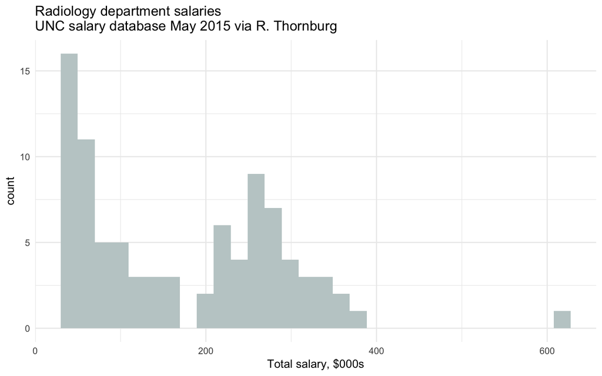

```r
# Notice figure size adjustments in chunk options
# No need to change variable names or fill colors for your answers or units
ggplot(radio_dept, aes(x = totalsal/1000)) + geom_histogram(fill = "azure3") +
  theme_minimal() + xlab("Total salary, $000s") + ggtitle("Radiology department salaries\nUNC salary database May 2015 via R. Thornburg")
```

## Question 6

Use faceting to make histograms of department salaries for Radiation Oncology, Radiology, Pediatrics, and Orthopaedics.

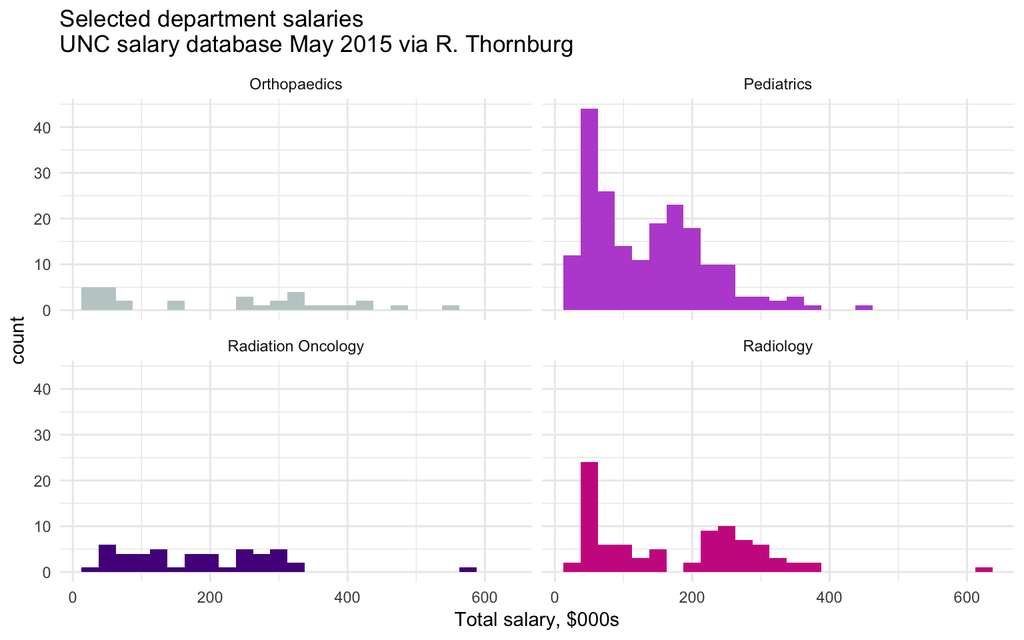

```r
# The color here is totally unnecessary and included just to show how you can manually suppress legends and set conditional colors

filter(data, dept %in% c("Radiation Oncology", "Radiology", "Pediatrics", "Orthopaedics")) %>%
  ggplot(aes(x = totalsal / 1000, fill = dept)) + geom_histogram(binwidth = 25) +
  facet_wrap(~ dept) +
  theme_minimal() + xlab("Total salary, $000s") + theme(legend.position = "none") +
  ggtitle("Selected department salaries\nUNC salary database May 2015 via R. Thornburg") +
  scale_fill_manual(values = c("azure3", "mediumorchid", "purple4", "maroon3"))
```

Use faceting to make plot age vs. totalsal for the same four departments and color points using the status variable.

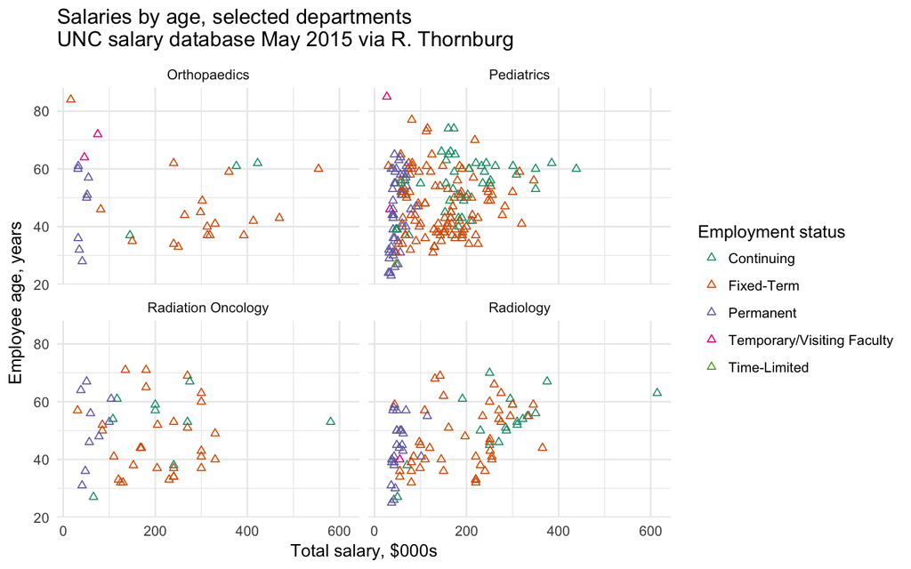

```r
# This package has some nice palettes, particularly for maps. See http://colorbrewer2.org/
library(RColorBrewer)

filter(data, dept %in% c("Radiation Oncology", "Radiology", "Pediatrics", "Orthopaedics")) %>%
  ggplot(aes(x = totalsal / 1000, y = age, color = status)) + geom_point(shape = 2) +
  facet_wrap(~ dept) +
  theme_minimal() + xlab("Total salary, $000s") + ylab("Employee age, years") +
  ggtitle("Salaries by age, selected departments\nUNC salary database May 2015 via R. Thornburg") +
  scale_color_brewer(name = "Employment status", type = "qual", palette = "Dark2")
```

## Question 7

Create a data frame called `dept_summary` whose rows are the departments and whose columns are: department size, mean department salary, median department salary, and maximum salary (using totalsal for salary).

```r
dept_summary <- group_by(data, dept) %>%
    summarise(dept_size = n(), mean_dept_totalsal = mean(totalsal),
              med_dept_totalsal = median(totalsal), max_dept_totalsal = max(totalsal))
```

Order the departments by highest mean salary and print the 10 highest paid departments.

```r
dept_summary %>%
    arrange(desc(mean_dept_totalsal)) %>%
    select(dept)
```

```
## # A tibble: 304 × 1
##                        dept
##                       <chr>
## 1              Neurosurgery
## 2                   Provost
## 3                   Urology
## 4              Orthopaedics
## 5                   Surgery
## 6            Anesthesiology
## 7        Radiation Oncology
## 8           Carolina Counts
## 9                 Radiology
## 10 Office of the Chancellor
## # ... with 294 more rows
```

Order the departments by highest median salary and print the 10 highest paid departments.

```r
dept_summary %>%
    arrange(desc(med_dept_totalsal)) %>%
    select(dept)
```

```
## # A tibble: 304 × 1
##                        dept
##                       <chr>
## 1              Neurosurgery
## 2                   Provost
## 3              Orthopaedics
## 4                   Urology
## 5            Anesthesiology
## 6           Carolina Counts
## 7        Radiation Oncology
## 8                   Surgery
## 9  University Ombuds Office
## 10    Ath Basketball Office
## # ... with 294 more rows
```

Why do these lists differ? If you were asked for the top 10 best paid departments at UNC which summary would you choose and why?

The lists differ because mean $\neq$ media in general: the former calculates the average of numbers and the latter finds the midpoint.

With the data above, the answer is fairly clear: Neurosurgery and Provost are the two best-paid offices, by both measures.

But the question is problematic. What does `best paid` really mean? If ever you get a question like this, make it more specific. What do you actually want to know from this data? What will this information be used to do?

If you want to know which department you can show up at, pick a person at random, and expect to find the largest salary (maybe after several random samples like this)—then go with the department with the largest average. People also like the sound of averages, another but bad reason you could use that list.

But the best thing to do is get more detailed distributional results—like the histograms we plotted above. You might be able to make more qualitative statements about the salary distribution for departments.

You could focus on the top departments in both of those lists, but remember: Both statistics are related to a measure of the center of the salary distribution. You might have a department with a large number of relatively poorly paid workers and a few very well paid ones. Who those people are might be relevant to your questions about salaries at UNC, or might prompt you to rethink your questions altogether.

## Question 8

How many departments have at least 10 employees?

```r
count(dept_summary, dept_size >= 10)
```

```
## # A tibble: 2 × 2
##   `dept_size >= 10`     n
##               <lgl> <int>
## 1             FALSE   110
## 2              TRUE   194
```

194 departments have at least 10 employees.

## Question 9

```r
library(lubridate)
mutate(data, hiredate = parse_datetime(hiredate, "%Y%m%d")) %>%
  filter(year(hiredate) == 2010) %>%
  group_by(dept) %>%
  summarise(N = n()) %>%
  arrange(desc(N))
```

```
## # A tibble: 169 × 2
##                             dept     N
##                            <chr> <int>
## 1                       Medicine    37
## 2    Comprehensive Cancer Center    36
## 3     FPG Child Development Inst    19
## 4     Laboratory Animal Medicine    19
## 5                     Psychiatry    19
## 6             School of Pharmacy    14
## 7        Medicine Administration    13
## 8   Information Technology Svcs.    12
## 9  Kenan-Flagler Business School    12
## 10         Housekeeping Services    11
## # ... with 159 more rows
```

The department of medicine hired the most people in 2010.

## Question 10

Make a list of all the department names and sort this list alphabetically. What is the 42nd department in this list?

```r
# in dplyr
select(data, dept) %>% distinct(dept) %>% arrange(dept) %>% slice(42)
```

```
## # A tibble: 1 × 1
##         dept
##        <chr>
## 1 Ath Soccer
```

```r
# in base R
sort(unique(data$dept))[42]
```

```
## [1] "Ath Soccer"
```

## Question 11

Plot number of people hired by the CS dept per year vs. year

*NOTE: If you interpreted `CS` to mean `Communication Studies` you did not lose points.*

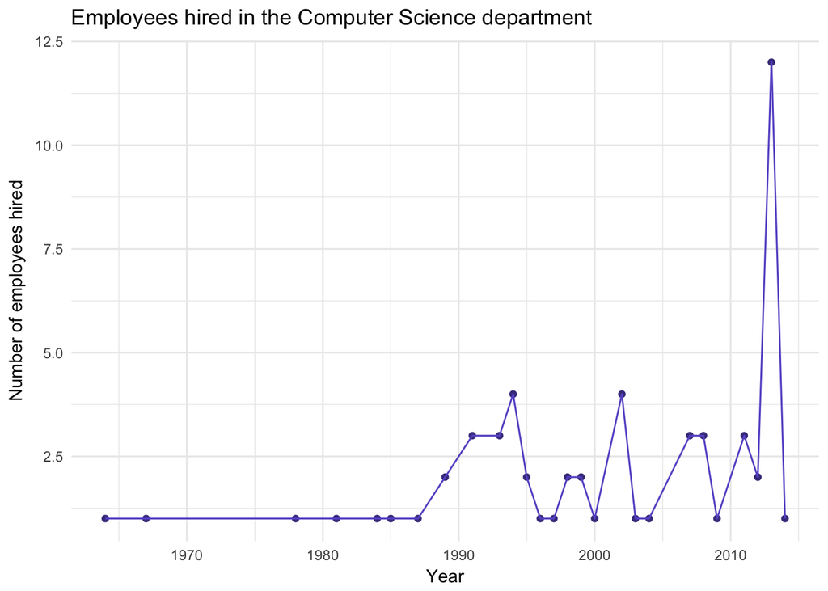

```r
hires <- filter(data,
                dept %in% c("Computer Science", "Statistics and Operations Res", "Mathematics",
                            "Biostatistics", "School of Info & Libr Science", "Physics-Astronomy")) %>%
  mutate(hiredate = parse_datetime(hiredate, "%Y%m%d"),
                yr = year(hiredate)) %>%
  group_by(yr, dept) %>%
  summarise(N = n()) %>%
  ungroup

filter(hires, dept == "Computer Science") %>%
  ggplot(aes(x = yr, y = N)) + theme_minimal() +
  geom_point(color = "slateblue4") +
  geom_line(color = "slateblue3") +
  ylab("Number of employees hired") + xlab("Year") +
  ggtitle("Employees hired in the Computer Science department")
```

Now add STOR, Math, Biostatistics, SILS and Physics to the above plot.

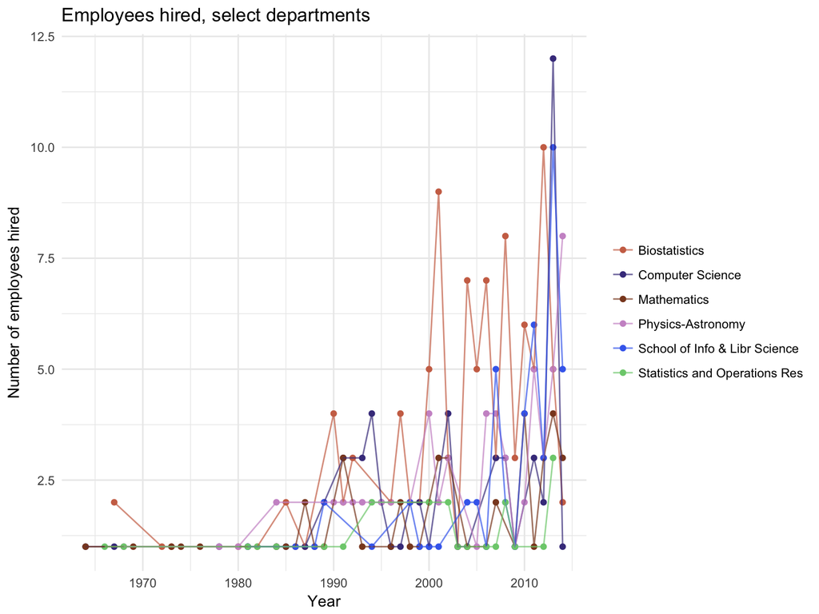

```r
ggplot(hires, aes(x = yr, y = N, color = dept)) + theme_minimal() +
  geom_point() +   geom_line(alpha = .7) +
  scale_color_manual(name = "", values = c("salmon3", "slateblue4", "sienna4", "plum3", "royalblue2", "palegreen3")) +
  ylab("Number of employees hired") + xlab("Year") +
  ggtitle("Employees hired, select departments")
```